# Homework #9: Association Analysis

Jie Tang

Due: Tue May 3 | 10:30 am

**SYS 4582/6018 | Spring 2022 | University of Virginia**

# Required R packages and Directories

```r
data.dir = 'https://mdporter.github.io/SYS6018/data/' # data directory
library(R6018)     # functions for DS-6018
library(arules)    # functions for Association Rules
library(tidyverse) # functions for data manipulation
# Add others if necessary
```

# Problem 1: Interestingness

Suppose we have market basket data consisting of 100 transactions and 20 items. Assume the support for item {$a$} is 20%, support for item {$b$} is 85%, and support for itemset {$a,b$} is 15%.

## a. What is the confidence of the rule {a} $\rightarrow$ {b}?

Support of {a} is 20% which means pr(a in T) = 20% Support of {b} is 85% which means pr(b in T) = 85% Support of {a,b} is 15% which means pr(a and b in T) = 15% The confidence of a rule is: – C(I → J) = S(I,J)/S(I) ˆ= Pr(I⊆T,J⊆T)/Pr(I⊆T) = P(J ⊆ T|I ⊆ T) So C(a -> b ) = 0.15/0.20 = 0.75

## b. Will the apriori algorithm find this rule (interesting) if the confidence threshold (minconf) is $c=.60$ and the support threshold (minsup) is $s=.10$?

Yes. Both {a} and {b} are frequent (have support larger than .10). And the confidence of rule {a} -> {b} is 75% which is larger than minconf.

## c. Find the *lift* of this rule.

Definition of lift is: L(I, J) = C(I → J)/S(J) So L(a, b) = 0.75/0.85 = 0.8824

## e. Find the *leverage/PS* of this rule.

Definition of leverage/PS is PS(I, J) = S(I, J) − S(I)S(J) So PS(a ,b) = 0.15 - 0.2*0.85 = -0.02

## g. Let $p(a)$, $p(b)$, and $p(a,b)$ be the actual probabilities of observing items {a}, {b}, and {a,b} respectively in a transaction. What is the expected confidence rule {a} $\rightarrow$ {b} if a and b are independent?

If item {a} and {b} are independent, it means that p(a,b) = p(a)*p(b). And confidence rule is calculated by C(I → J) = S(I,J)/S(I) = Pr(I⊆T,J⊆T)/Pr(I⊆T). It would be p(a,b)/p(a) = p(a)p(b)/p(a) = p(b). It is the probabilities of itms {b} if they are independent. It makes sense because if they have no relation between each other, prob of b that a alread in basket will be equal to prob of b with nothing in basket.

# Problem 2: Online Retail

The website http://archive.ics.uci.edu/ml/datasets/online+retail describes some transactional data from an online retailer.

## a. Download the [excel file](http://archive.ics.uci.edu/ml/machine-learning-databases/00352/Online%20Retail.xlsx) to your machine and read it into R.

- Loading Excel data: `readxl::read_excel()` (part of tidyverse)

```r
data = readxl::read_excel('Online Retail.xlsx')
```

## b. There are many quality problems with this dataset, but we will only address two of them. Remove all of the rows with missing Description values (NAs) and remove any duplicate items in a single transaction. Print the first 10 rows of the resulting data.

```r
#check whether there is NAs in Description values
any(is.na(data$Description))
```

```
#> [1] TRUE
```

```r
print("Original data length")
```

```
#> [1] "Original data length"
```

```r
print(length(data$Description))
```

```
#> [1] 541909
```

```r
#drop NAs
data <- data[!is.na(data$Description),]
print("After drop NAs")
```

```
#> [1] "After drop NAs"
```

```r
print(length(data$Description))
```

```
#> [1] 540455
```

```r
data <- data %>% distinct(InvoiceNo, StockCode, .keep_all = TRUE)
print("After removing duplicated")
```

```
#> [1] "After removing duplicated"
```

```r
print(length(data$Description))
```

```
#> [1] 529771
```

```r
head(data, 10)
```

| InvoiceNo | StockCode | Description | Quantity | InvoiceDate | UnitPrice | CustomerID | Country |
| --- | --- | --- | --- | --- | --- | --- | --- |
| 536365 | 85123A | WHITE HANGING HEART T-LIGHT HOLDER | 6 | 2010-12-01 08:26:00 | 2.55 | 17850 | United Kingdom |
| 536365 | 71053 | WHITE METAL LANTERN | 6 | 2010-12-01 08:26:00 | 3.39 | 17850 | United Kingdom |
| 536365 | 84406B | CREAM CUPID HEARTS COAT HANGER | 8 | 2010-12-01 08:26:00 | 2.75 | 17850 | United Kingdom |
| 536365 | 84029G | KNITTED UNION FLAG HOT WATER BOTTLE | 6 | 2010-12-01 08:26:00 | 3.39 | 17850 | United Kingdom |
| 536365 | 84029E | RED WOOLLY HOTTIE WHITE HEART. | 6 | 2010-12-01 08:26:00 | 3.39 | 17850 | United Kingdom |
| 536365 | 22752 | SET 7 BABUSHKA NESTING BOXES | 2 | 2010-12-01 08:26:00 | 7.65 | 17850 | United Kingdom |
| 536365 | 21730 | GLASS STAR FROSTED T-LIGHT HOLDER | 6 | 2010-12-01 08:26:00 | 4.25 | 17850 | United Kingdom |
| 536366 | 22633 | HAND WARMER UNION JACK | 6 | 2010-12-01 08:28:00 | 1.85 | 17850 | United Kingdom |
| 536366 | 22632 | HAND WARMER RED POLKA DOT | 6 | 2010-12-01 08:28:00 | 1.85 | 17850 | United Kingdom |
| 536367 | 84879 | ASSORTED COLOUR BIRD ORNAMENT | 32 | 2010-12-01 08:34:00 | 1.69 | 13047 | United Kingdom |

## c. Find the number of transactions and number of items using *InvoiceNo* for transactions and *Description* as items (i.e., ignore the *StockCode* column).

```r
NT = n_distinct(data$InvoiceNo)     # Number of transactions
NI = n_distinct(data$Description) # Number of items
print(NT)
```

```
#> [1] 24446
```

```r
print(NI)
```

```
#> [1] 4211
```

## d. Convert the data frame into a *transaction list* and convert it into a *transactions object* (don’t forget to load the `arules` package). Print a summary (using `summary()`) of the new object.

```r
#-- get transaction list
tList = split(data$Description, data$InvoiceNo)    # get transaction list
# tList = lapply(tList, unique)              # another way to remove duplicates

#-- get transaction class
library(arules)
trans = as(tList, "transactions")
summary(trans)
```

```
#> transactions as itemMatrix in sparse format with
#>  24446 rows (elements/itemsets/transactions) and
#>  4211 columns (items) and a density of 0.005143
#>
#> most frequent items:
#> WHITE HANGING HEART T-LIGHT HOLDER           REGENCY CAKESTAND 3 TIER
#>                               2302                               2169
#>            JUMBO BAG RED RETROSPOT                      PARTY BUNTING
#>                               2135                               1706
#>            LUNCH BAG RED RETROSPOT                            (Other)
#>                               1607                             519556
#>
#> element (itemset/transaction) length distribution:
#> sizes
#>    1    2    3    4    5    6    7    8    9   10   11   12   13   14   15   16
```

[output cut: 62 more lines]

## e. Find the items with the highest support. Print and plot the support of the top 10.

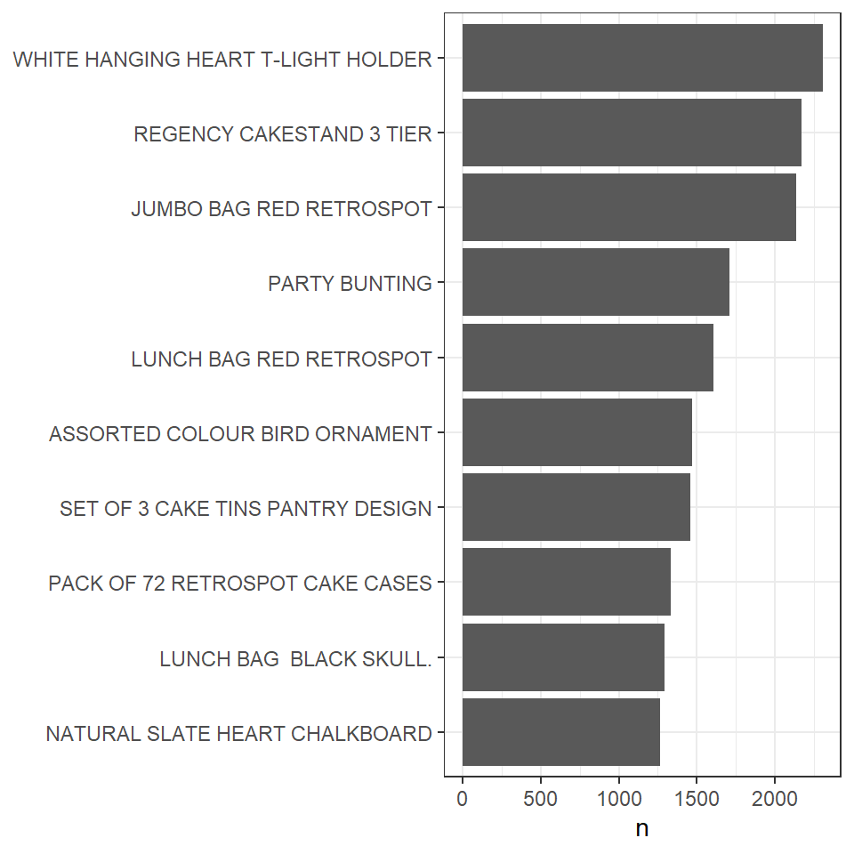

```r
#-- get item counts and support for single itemsets
itemFreq = count(data, Description, sort=TRUE) %>% mutate(support=n/NT)


# plot top 10
itemFreq %>% slice(1:10) %>%
  ggplot(aes(fct_reorder(Description, n), n)) + # order bars by n
  geom_col() +         # barplot
  coord_flip() +       # rotate plot 90 deg
  theme(axis.title.y = element_blank()) # remove y axis title
```

## f. Find the *frequent itemsets* that contain at least 3 items and have $s\geq 0.02$. Add the *lift* metric. Show all results, ordered by *lift*.

```r
#-- Find all frequent itemsets (s=.02) of length 3 (minlen=3)
fis2 = apriori(trans,
               parameter = list(support = .02, minlen=3, target="frequent"))
```

```
#> Apriori
#>
#> Parameter specification:
#>  confidence minval smax arem  aval originalSupport maxtime support minlen
#>          NA    0.1    1 none FALSE            TRUE       5    0.02      3
#>  maxlen            target  ext
#>      10 frequent itemsets TRUE
#>
#> Algorithmic control:
#>  filter tree heap memopt load sort verbose
#>     0.1 TRUE TRUE  FALSE TRUE    2    TRUE
#>
#> Absolute minimum support count: 488
#>
#> set item appearances ...[0 item(s)] done [0.00s].
#> set transactions ...[4211 item(s), 24446 transaction(s)] done [0.20s].
#> sorting and recoding items ... [202 item(s)] done [0.00s].
#> creating transaction tree ... done [0.01s].
#> checking subsets of size 1 2 3 done [0.00s].
#> sorting transactions ... done [0.00s].
#> writing ... [1 set(s)] done [0.00s].
#> creating S4 object  ... done [0.01s].
```

```r
apriori2df(fis2) %>% arrange(-support)  # order by support (largest to smallest)
```

| items | support | count |
| --- | --- | --- |
| {GREEN REGENCY TEACUP AND SAUCER,PINK REGENCY TEACUP AND SAUCER,ROSES REGENCY TEACUP AND SAUCER} | 0.02246 | 549 |

```r
#-- Add lift using the interestMeasure() function
apriori2df(fis2) %>%
  mutate(lift = interestMeasure(fis2, measure="lift", trans)) %>%
  arrange(-lift)
```

| items | support | count | lift |
| --- | --- | --- | --- |
| {GREEN REGENCY TEACUP AND SAUCER,PINK REGENCY TEACUP AND SAUCER,ROSES REGENCY TEACUP AND SAUCER} | 0.02246 | 549 | 346 |

## g. Find all of the *association rules* with $s \geq 0.02$, $c \geq 0.70$. Add the *PS/leverage* and *addedValue* metrics. Show all results, ordered by *addedValue*

```r
#-- Find association rules with support>=.02 and confidence>=.70
rules = apriori(trans,
             parameter = list(support=.02, confidence=.70,
                              minlen=2,target="rules"))
```

```
#> Apriori
#>
#> Parameter specification:
#>  confidence minval smax arem  aval originalSupport maxtime support minlen
#>         0.7    0.1    1 none FALSE            TRUE       5    0.02      2
#>  maxlen target  ext
#>      10  rules TRUE
#>
#> Algorithmic control:
#>  filter tree heap memopt load sort verbose
#>     0.1 TRUE TRUE  FALSE TRUE    2    TRUE
#>
#> Absolute minimum support count: 488
#>
#> set item appearances ...[0 item(s)] done [0.00s].
#> set transactions ...[4211 item(s), 24446 transaction(s)] done [0.18s].
#> sorting and recoding items ... [202 item(s)] done [0.00s].
#> creating transaction tree ... done [0.01s].
#> checking subsets of size 1 2 3 done [0.00s].
#> writing ... [8 rule(s)] done [0.00s].
#> creating S4 object  ... done [0.00s].
```

```r
apriori2df(rules) %>% arrange(-confidence)  # order by confidence metric
```

| lhs | rhs | support | confidence | coverage | lift | count |
| --- | --- | --- | --- | --- | --- | --- |
| {PINK REGENCY TEACUP AND SAUCER,ROSES REGENCY TEACUP AND SAUCER} | {GREEN REGENCY TEACUP AND SAUCER} | 0.02246 | 0.8941 | 0.02512 | 20.68 | 549 |
| {GREEN REGENCY TEACUP AND SAUCER,PINK REGENCY TEACUP AND SAUCER} | {ROSES REGENCY TEACUP AND SAUCER} | 0.02246 | 0.8525 | 0.02634 | 18.61 | 549 |
| {PINK REGENCY TEACUP AND SAUCER} | {GREEN REGENCY TEACUP AND SAUCER} | 0.02634 | 0.8040 | 0.03277 | 18.59 | 644 |
| {PINK REGENCY TEACUP AND SAUCER} | {ROSES REGENCY TEACUP AND SAUCER} | 0.02512 | 0.7665 | 0.03277 | 16.73 | 614 |
| {GREEN REGENCY TEACUP AND SAUCER} | {ROSES REGENCY TEACUP AND SAUCER} | 0.03207 | 0.7417 | 0.04324 | 16.19 | 784 |
| {GARDENERS KNEELING PAD CUP OF TEA} | {GARDENERS KNEELING PAD KEEP CALM} | 0.02246 | 0.7176 | 0.03129 | 18.99 | 549 |
| {GREEN REGENCY TEACUP AND SAUCER,ROSES REGENCY TEACUP AND SAUCER} | {PINK REGENCY TEACUP AND SAUCER} | 0.02246 | 0.7003 | 0.03207 | 21.37 | 549 |
| {ROSES REGENCY TEACUP AND SAUCER} | {GREEN REGENCY TEACUP AND SAUCER} | 0.03207 | 0.7000 | 0.04582 | 16.19 | 784 |

```r
apriori2df(rules) %>% arrange(-lift)        # order by lift metric
```

| lhs | rhs | support | confidence | coverage | lift | count |
| --- | --- | --- | --- | --- | --- | --- |
| {GREEN REGENCY TEACUP AND SAUCER,ROSES REGENCY TEACUP AND SAUCER} | {PINK REGENCY TEACUP AND SAUCER} | 0.02246 | 0.7003 | 0.03207 | 21.37 | 549 |
| {PINK REGENCY TEACUP AND SAUCER,ROSES REGENCY TEACUP AND SAUCER} | {GREEN REGENCY TEACUP AND SAUCER} | 0.02246 | 0.8941 | 0.02512 | 20.68 | 549 |
| {GARDENERS KNEELING PAD CUP OF TEA} | {GARDENERS KNEELING PAD KEEP CALM} | 0.02246 | 0.7176 | 0.03129 | 18.99 | 549 |
| {GREEN REGENCY TEACUP AND SAUCER,PINK REGENCY TEACUP AND SAUCER} | {ROSES REGENCY TEACUP AND SAUCER} | 0.02246 | 0.8525 | 0.02634 | 18.61 | 549 |
| {PINK REGENCY TEACUP AND SAUCER} | {GREEN REGENCY TEACUP AND SAUCER} | 0.02634 | 0.8040 | 0.03277 | 18.59 | 644 |
| {PINK REGENCY TEACUP AND SAUCER} | {ROSES REGENCY TEACUP AND SAUCER} | 0.02512 | 0.7665 | 0.03277 | 16.73 | 614 |
| {ROSES REGENCY TEACUP AND SAUCER} | {GREEN REGENCY TEACUP AND SAUCER} | 0.03207 | 0.7000 | 0.04582 | 16.19 | 784 |
| {GREEN REGENCY TEACUP AND SAUCER} | {ROSES REGENCY TEACUP AND SAUCER} | 0.03207 | 0.7417 | 0.04324 | 16.19 | 784 |

```r
#-- Add other interest measures
apriori2df(rules) %>%
  mutate(addedValue = interestMeasure(rules, measure="addedValue", trans),
         PS = interestMeasure(rules, measure="leverage", trans)) %>%
  arrange(-addedValue)
```

| lhs | rhs | support | confidence | coverage | lift | count | addedValue | PS |
| --- | --- | --- | --- | --- | --- | --- | --- | --- |
| {PINK REGENCY TEACUP AND SAUCER,ROSES REGENCY TEACUP AND SAUCER} | {GREEN REGENCY TEACUP AND SAUCER} | 0.02246 | 0.8941 | 0.02512 | 20.68 | 549 | 0.8509 | 0.02137 |
| {GREEN REGENCY TEACUP AND SAUCER,PINK REGENCY TEACUP AND SAUCER} | {ROSES REGENCY TEACUP AND SAUCER} | 0.02246 | 0.8525 | 0.02634 | 18.61 | 549 | 0.8067 | 0.02125 |
| {PINK REGENCY TEACUP AND SAUCER} | {GREEN REGENCY TEACUP AND SAUCER} | 0.02634 | 0.8040 | 0.03277 | 18.59 | 644 | 0.7608 | 0.02493 |
| {PINK REGENCY TEACUP AND SAUCER} | {ROSES REGENCY TEACUP AND SAUCER} | 0.02512 | 0.7665 | 0.03277 | 16.73 | 614 | 0.7207 | 0.02362 |
| {GREEN REGENCY TEACUP AND SAUCER} | {ROSES REGENCY TEACUP AND SAUCER} | 0.03207 | 0.7417 | 0.04324 | 16.19 | 784 | 0.6959 | 0.03009 |
| {GARDENERS KNEELING PAD CUP OF TEA} | {GARDENERS KNEELING PAD KEEP CALM} | 0.02246 | 0.7176 | 0.03129 | 18.99 | 549 | 0.6798 | 0.02127 |
| {GREEN REGENCY TEACUP AND SAUCER,ROSES REGENCY TEACUP AND SAUCER} | {PINK REGENCY TEACUP AND SAUCER} | 0.02246 | 0.7003 | 0.03207 | 21.37 | 549 | 0.6675 | 0.02141 |
| {ROSES REGENCY TEACUP AND SAUCER} | {GREEN REGENCY TEACUP AND SAUCER} | 0.03207 | 0.7000 | 0.04582 | 16.19 | 784 | 0.6568 | 0.03009 |